# Mutations, Diversity, Burden and Minority Variants

A hands-on workshop using HIV-1 deep-sequencing data (NC_001802.1)

Dr. W. Choga

17 July 2026

> **How to use this document.** Every number in the prose is computed from the data, not typed in. Run it top-to-bottom.

> **This is not a canned demo.** Partway through, our first analysis will produce a confident, FDR-significant result that turns out to be **an artefact**. We will catch it, diagnose it, and fix it. That reversal is the most important thing in this workshop.

# 1 The dataset

A **per-position pileup** from a whole-genome HIV-1 deep-sequencing run, aligned to **NC_001802.1** (the RefSeq HIV-1 HXB2 reference, 9,181 bp).

| Column | Meaning |
| --- | --- |
| `Nucleotide pos` | position on the reference genome (1–9181) |
| `Nucleotide ref` | the **reference** base at that position |
| `Nucleotide strain` | the **consensus** base called for *this* sample |
| `Depth of coverage (high quality)` | reads passing quality filter |
| `A/C/G/T count (high quality)` | how many reads showed each base |
| `indel count` | reads supporting an insertion/deletion |
| `Depth of coverage (raw)` | reads before quality filtering |

The A/C/G/T counts are the whole point: they let us see **below the consensus**, into the minority population. A consensus FASTA throws that away.

```r
raw <- readr::read_csv(params$csv, trim_ws = TRUE, show_col_types = FALSE)

# Header has spaces/parentheses; rename positionally so the code is robust.
names(raw) <- c("pos", "ref", "strain", "depth_hq",
                "A", "C", "G", "T", "indel_count", "depth_raw")

dat <- raw %>%
  mutate(
    across(c(pos, depth_hq, A, C, G, T, indel_count, depth_raw), as.numeric),
    indel_count = replace_na(indel_count, 0),
    ref    = str_trim(ref),
    strain = str_trim(strain)
  )

dim(dat)
```

```
## [1] 9131   10
```

```r
head(dat, 5)
```

| pos | ref | strain | depth_hq | A | C | G | T | indel_count | depth_raw |
| --- | --- | --- | --- | --- | --- | --- | --- | --- | --- |
| 1 | G | G | 1071 | 0 | 0 | 1070 | 1 | 0 | 1688 |
| 2 | G | G | 13547 | 0 | 2 | 13535 | 10 | 0 | 15399 |
| 3 | T | T | 18807 | 11 | 2 | 4 | 18790 | 0 | 20951 |
| 4 | C | C | 18910 | 30 | 18880 | 0 | 0 | 0 | 21054 |
| 5 | T | T | 18933 | 23 | 3 | 0 | 18907 | 0 | 21080 |

## 1.1 Row types: not every row is a SNP

There are **three** kinds of row here, and a two-way split silently turns the third into `NA`:

1. **SNP-comparable** — single ref base, single consensus base, real counts.
2. **indel record** — multi-base `ref` or `strain`, no depth/counts.
3. **zero-coverage** — *empty* `strain`: no reads at all, so no consensus could be called. These are **not deletions** — they were simply never sequenced.

```r
dat <- dat %>%
  mutate(row_type = case_when(
    is.na(strain) | strain == ""          ~ "zero-coverage (no call)",
    nchar(ref) == 1 & nchar(strain) == 1  ~ "SNP-comparable",
    TRUE                                  ~ "indel record"
  ))

count(dat, row_type) %>% kable(caption = "Row types in the file")
```

Row types in the file

| row_type | n |
| --- | --- |
| SNP-comparable | 9005 |
| indel record | 26 |
| zero-coverage (no call) | 100 |

```r
snp  <- filter(dat, row_type == "SNP-comparable")
ind  <- filter(dat, row_type == "indel record")
nocv <- filter(dat, row_type == "zero-coverage (no call)")

ind %>% select(pos, ref, strain, indel_count) %>% head(8) %>%
  kable(caption = "Example indel records (multi-base ref or strain)")
```

Example indel records (multi-base ref or strain)

| pos | ref | strain | indel_count |
| --- | --- | --- | --- |
| 279 | GG | G | 28659 |
| 306 | T | TA | 29226 |
| 704 | ACACAGCAAT | A | 5961 |
| 1454 | AGCT | A | 4303 |
| 1729 | CTGGGGT | T | 5436 |
| 1781 | ACTGTAT | A | 5169 |
| 5319 | TT | T | 6476 |
| 5599 | GTAC | T | 3829 |

> **A trap worth knowing.** `nchar(NA)` is `NA`, not `0`. So `filter(nchar(strain) == 1)` evaluates to `NA` for the zero-coverage rows and **dplyr drops them without a word**. You lose 100 rows and nothing tells you. Here they sit at positions 9082–9181 — the 3’ tail the sequencing never reached. The depth filter would have excluded them anyway, so no number below changes — but “silently dropped” and “correctly excluded” are different things, and only one of them is reproducible.

## 1.2 Coverage QC — before any variant calling

**You cannot call a variant you did not sequence deeply enough to see.**

```r
snp %>% summarise(
  sites = n(), zero_depth = sum(depth_hq == 0),
  median_depth = median(depth_hq), min_depth = min(depth_hq), max_depth = max(depth_hq)
) %>% kable(caption = "High-quality depth summary")
```

High-quality depth summary

| sites | zero_depth | median_depth | min_depth | max_depth |
| --- | --- | --- | --- | --- |
| 9005 | 0 | 4002 | 2 | 31797 |

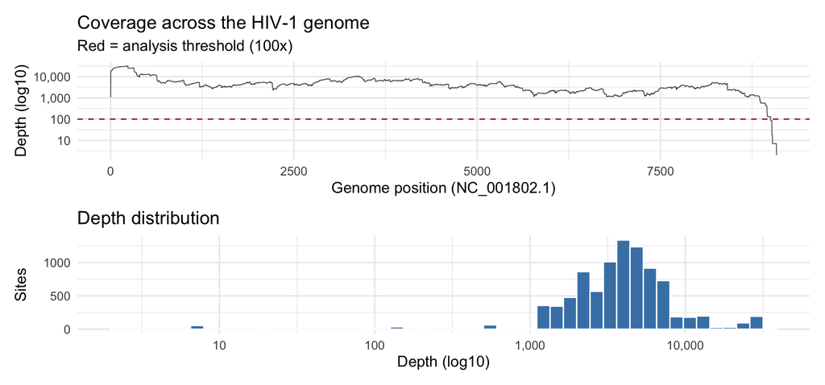

```r
p_cov <- ggplot(snp, aes(pos, depth_hq)) +
  geom_line(linewidth = 0.3, colour = "grey30") +
  geom_hline(yintercept = params$min_depth, colour = "firebrick", linetype = 2) +
  scale_y_log10(labels = scales::comma) +
  labs(title = "Coverage across the HIV-1 genome",
       subtitle = paste0("Red = analysis threshold (", params$min_depth, "x)"),
       x = "Genome position (NC_001802.1)", y = "Depth (log10)")

p_hist <- ggplot(snp, aes(depth_hq)) +
  geom_histogram(bins = 50, fill = "steelblue", colour = "white") +
  scale_x_log10(labels = scales::comma) +
  labs(title = "Depth distribution", x = "Depth (log10)", y = "Sites")

p_cov / p_hist
```

```r
callable <- snp %>%
  mutate(total = A + C + G + T) %>%
  filter(depth_hq >= params$min_depth, total >= params$min_depth)

cat(sprintf("Callable sites: %s of %s (%.1f%%)\n",
            format(nrow(callable), big.mark = ","),
            format(nrow(snp), big.mark = ","),
            100 * nrow(callable) / nrow(snp)))
```

```
## Callable sites: 8,924 of 9,005 (99.1%)
```

Coverage is not uniform. Low-coverage sites have a **worse limit of detection**. “No variant found” at 500× and at 20,000× are not the same statement.

# 2 What is a mutation?

A **mutation** is a change in sequence relative to a reference. Three things must be pinned down before the word means anything:

1. **Relative to what?** Reference genome? The patient’s own baseline? “Mutation” is always a *comparison*.
2. **In what fraction of the population?** In a virus you have a *population* of genomes. A change in 100% of them and in 2% of them are both real — and mean different things.
3. **With what confidence?** Sequencers make errors. A 0.3% signal may be a mutation or noise.

Two comparisons are available in this file:

- `ref` vs `strain` → **consensus mutations** (Sanger would see these too)
- `strain` vs the **base counts** → **minority variants** (deep sequencing only)

## 2.1 Consensus mutations (ref vs strain)

```r
cons <- callable %>% filter(ref != strain)

cat(sprintf("Consensus mutations: %s\n", format(nrow(cons), big.mark = ",")))
```

```
## Consensus mutations: 1,287
```

```r
cat(sprintf("Divergence from reference: %.2f%% of callable sites\n",
            100 * nrow(cons) / nrow(callable)))
```

```
## Divergence from reference: 14.42% of callable sites
```

```r
cons %>% count(ref, strain, name = "n") %>% arrange(desc(n)) %>% head(12) %>%
  kable(caption = "Most common reference -> sample consensus changes")
```

Most common reference -> sample consensus changes

| ref | strain | n |
| --- | --- | --- |
| G | A | 269 |
| A | G | 241 |
| C | T | 155 |
| T | C | 150 |
| C | A | 99 |
| A | C | 94 |
| A | T | 76 |
| T | A | 61 |
| G | C | 39 |
| T | G | 39 |
| C | G | 33 |
| G | T | 31 |

**Interpretation.** ~14% divergence is enormous — and expected. This sample is almost certainly a **non-subtype-B** virus compared against a **subtype-B reference (HXB2)**. Most of these are **subtype differences**: evolution that happened long before this infection.

> **A difference from the reference is not a mutation that arose in your sample.** The reference is a historical accident, not a wild-type ideal.

# 3 Types of mutation

Independent axes — do not mix them up.

## 3.1 By structural change

| Type | What happens | In this file |
| --- | --- | --- |
| **Substitution (SNV/SNP)** | one base swapped | `ref` and `strain` both 1 base |
| **Insertion** | bases added | `strain` longer than `ref` |
| **Deletion** | bases removed | `ref` longer than `strain` |

```r
ind_class <- ind %>%
  mutate(
    indel_type = case_when(nchar(strain) > nchar(ref) ~ "Insertion",
                           nchar(strain) < nchar(ref) ~ "Deletion",
                           TRUE ~ "Complex/other"),
    size  = abs(nchar(ref) - nchar(strain)),
    frame = if_else(size %% 3 == 0, "In-frame (x3)", "Frameshift")
  )

count(ind_class, indel_type, frame) %>%
  kable(caption = "Indel records by type and reading-frame effect")
```

Indel records by type and reading-frame effect

| indel_type | frame | n |
| --- | --- | --- |
| Deletion | Frameshift | 4 |
| Deletion | In-frame (x3) | 13 |
| Insertion | Frameshift | 1 |
| Insertion | In-frame (x3) | 8 |

**Why frame matters.** An indel sized in multiples of 3 adds/removes whole codons — the protein is shorter but readable. Any other size **shifts the reading frame**, garbling every downstream codon. Same “one mutation”, wildly different consequence.

Note most indels here are **in-frame** — consistent with real viral variation rather than random error, which has no reason to respect codon boundaries.

## 3.2 By biochemistry: transitions vs transversions

- **Transition (Ti)**: purine↔︎purine (A↔︎G) or pyrimidine↔︎pyrimidine (C↔︎T)
- **Transversion (Tv)**: purine↔︎pyrimidine

There are **8 possible transversions but only 4 transitions**, so pure chance predicts **Ti/Tv = 0.5**. Real data runs much higher (~2 genome-wide in humans) because transitions are mechanistically favoured and more often synonymous.

```r
is_transition <- function(a, b) {
  paste0(pmin(a, b), pmax(a, b)) %in% c("AG", "CT")
}

cons_titv <- cons %>%
  mutate(class = if_else(is_transition(ref, strain), "Transition", "Transversion"))

titv_tab <- count(cons_titv, class)
titv_ratio <- with(titv_tab, n[class == "Transition"] / n[class == "Transversion"])

kable(titv_tab, caption = "Consensus mutations by substitution class")
```

Consensus mutations by substitution class

| class | n |
| --- | --- |
| Transition | 815 |
| Transversion | 472 |

```r
cat(sprintf("Consensus Ti/Tv = %.2f  (chance alone would give 0.50)\n", titv_ratio))
```

```
## Consensus Ti/Tv = 1.73  (chance alone would give 0.50)
```

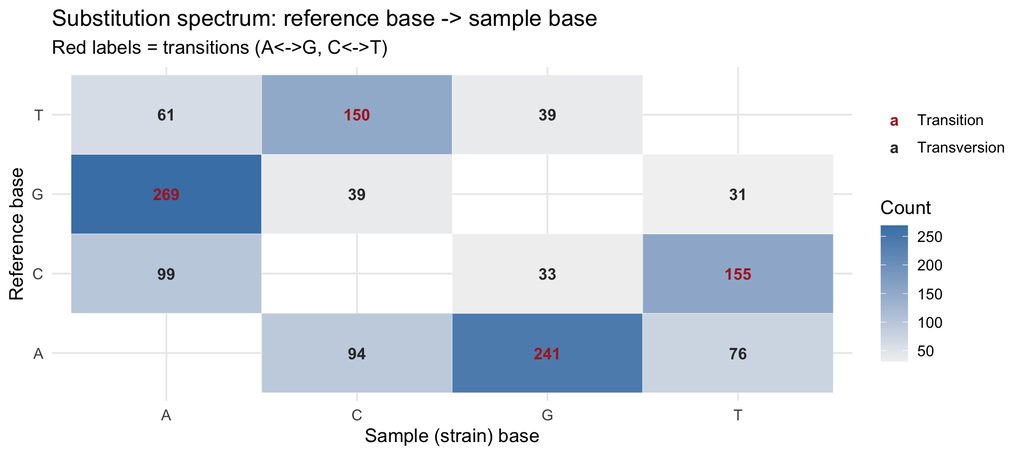

```r
cons %>% count(ref, strain) %>%
  mutate(class = if_else(is_transition(ref, strain), "Transition", "Transversion")) %>%
  ggplot(aes(strain, ref, fill = n)) +
  geom_tile(colour = "white") +
  geom_text(aes(label = n, colour = class), size = 3.6, fontface = "bold") +
  scale_fill_gradient(low = "grey95", high = "steelblue") +
  scale_colour_manual(values = c("Transition" = "firebrick", "Transversion" = "grey20")) +
  labs(title = "Substitution spectrum: reference base -> sample base",
       subtitle = "Red labels = transitions (A<->G, C<->T)",
       x = "Sample (strain) base", y = "Reference base", fill = "Count", colour = NULL)
```

Ti/Tv ≈ 1.7 — comfortably above the 0.5 noise line. These consensus differences are real evolutionary signal.

## 3.3 By functional consequence (coding effect)

Requires the reading frame, so it cannot be read off a pileup alone — but it is what clinicians care about.

| Class | Effect on protein | Example |
| --- | --- | --- |
| **Synonymous (silent)** | codon changes, amino acid does not | GGA→GGG, both Gly |
| **Missense** | one amino acid replaced | HIV RT `K103N` |
| **Nonsense** | codon → STOP, truncated | usually lethal to the virus |
| **Frameshift** | indel not ×3, downstream garbled | usually knockout |
| **Non-coding / regulatory** | outside genes | LTR promoter |

**dN/dS** is the classic selection test: < 1 purifying, ≈ 1 neutral, > 1 positive (diversifying) selection — the signature of immune escape and drug pressure.

## 3.4 By origin

**Germline** (inherited) vs **somatic** (acquired — the basis of cancer genomics). For a virus: **transmitted** vs **acquired** — which, for HIV drug resistance, decides whether a first-line regimen was ever going to work.

### 3.4.1 Exercise 1

Consensus Ti/Tv was ~1.7. Predict now whether the **minority-variant** Ti/Tv will be higher or lower, and why. Write it down before section 7.

# 4 How to calculate mutations

## 4.1 The core quantity: allele frequency (VAF)

$$\text{VAF}_{b} =
\frac{n_b}{n_A+n_C+n_G+n_T}$$

Everything downstream — minority calls, diversity, burden — is built on this.

```r
freq <- callable %>%
  mutate(across(c(A, C, G, T), ~ .x / total, .names = "f_{.col}")) %>%
  rowwise() %>%
  mutate(
    major_base = c("A", "C", "G", "T")[which.max(c(A, C, G, T))],
    major_f    = max(c(f_A, f_C, f_G, f_T)),
    minor_base = c("A", "C", "G", "T")[order(c(A, C, G, T), decreasing = TRUE)[2]],
    minor_f    = sort(c(f_A, f_C, f_G, f_T), decreasing = TRUE)[2],
    minor_n    = sort(c(A, C, G, T), decreasing = TRUE)[2]
  ) %>%
  ungroup() %>%
  mutate(change = paste0(major_base, ">", minor_base))

freq %>% select(pos, ref, strain, depth_hq, major_base, major_f, minor_base, minor_f) %>%
  head(6)
```

| pos | ref | strain | depth_hq | major_base | major_f | minor_base | minor_f |
| --- | --- | --- | --- | --- | --- | --- | --- |
| 1 | G | G | 1071 | G | 0.9990663 | T | 0.0009337068 |
| 2 | G | G | 13547 | G | 0.9991142 | T | 0.0007381708 |
| 3 | T | T | 18807 | T | 0.9990961 | A | 0.0005848886 |
| 4 | C | C | 18910 | C | 0.9984135 | A | 0.0015864622 |
| 5 | T | T | 18933 | T | 0.9986267 | A | 0.0012148101 |
| 6 | C | C | 19071 | C | 0.9984794 | A | 0.0014681978 |

Sanity check — the file’s consensus should equal our computed majority base:

```r
cat(sprintf("Agreement between file consensus and our majority base: %.2f%%\n",
            100 * mean(freq$major_base == freq$strain)))
```

```
## Agreement between file consensus and our majority base: 100.00%
```

## 4.2 Mutation frequency vs mutation rate — do not confuse them

|  | **Mutation frequency** | **Mutation rate** |
| --- | --- | --- |
| Question | *How many* mutants **now**? | How *fast* do new ones appear? |
| Units | proportion | per base **per replication** |
| Needs | one sample | ≥2 timepoints, or known generations |
| From this file? | **Yes** | **No** |

Frequency is a **snapshot** — the product of mutation *and* selection *and* drift *and* elapsed time. A high-frequency variant may be common because it arose often, or because it was *favoured*.

```r
genome_len <- 9181
hiv_rate   <- 2.4e-5   # mutations per base per replication cycle
virions    <- 1e10     # produced per day, untreated

cat(sprintf("Expected new mutations per genome per cycle: %.2f\n", hiv_rate * genome_len))
```

```
## Expected new mutations per genome per cycle: 0.22
```

```r
cat(sprintf("Every possible single-base mutation is generated ~%.0f times per day\n",
            hiv_rate * virions))
```

```
## Every possible single-base mutation is generated ~240000 times per day
```

That second number is the whole ballgame: **every possible point mutation is created many times a day**. Resistance is not a question of whether it is generated — only whether the drug gives it a reason to expand.

# 5 Diversity

Divergence asks “how far from the reference?”. **Diversity** asks **“how variable is the population within itself?”** A sample can be far from the reference yet uniform, or sit on the reference and be a seething swarm.

This is the **quasispecies** concept: an infection is not *a* virus, it is a cloud of related genomes.

## 5.1 Shannon entropy (per site)

$$H = -\sum_{b \in \{A,C,G,T\}} p_b \ln
p_b$$

$H = 0$ = invariant site. $H = \ln 4 = 1.386$ = all four bases equally likely.

```r
shannon <- function(p) { p <- p[p > 0]; -sum(p * log(p)) }

div <- freq %>%
  rowwise() %>%
  mutate(H = shannon(c(f_A, f_C, f_G, f_T))) %>%
  ungroup()

cat(sprintf("Mean Shannon entropy: %.4f  (max = %.3f)\n", mean(div$H), log(4)))
```

```
## Mean Shannon entropy: 0.0262  (max = 1.386)
```

```r
cat(sprintf("Sites with H > 0.1: %d\n", sum(div$H > 0.1)))
```

```
## Sites with H > 0.1: 185
```

## 5.2 Nucleotide diversity (π)

π is the **probability that two randomly drawn reads differ** at a site. Use the sample-size-corrected estimator:

$$\hat{\pi}_{\text{site}} =
\frac{n}{n-1}\left(1 - \sum_b p_b^2\right)$$

The $\frac{n}{n-1}$ term matters: without it, low-coverage sites look artificially *less* diverse purely because you sampled fewer reads.

```r
div <- div %>%
  mutate(pi_site = (total / (total - 1)) * (1 - (f_A^2 + f_C^2 + f_G^2 + f_T^2)))

cat(sprintf("Genome-wide nucleotide diversity, pi = %.5f\n", mean(div$pi_site)))
```

```
## Genome-wide nucleotide diversity, pi = 0.00810
```

```r
cat(sprintf("  i.e. two random reads differ at ~%.1f of every 10,000 bases\n",
            10000 * mean(div$pi_site)))
```

```
##   i.e. two random reads differ at ~81.0 of every 10,000 bases
```

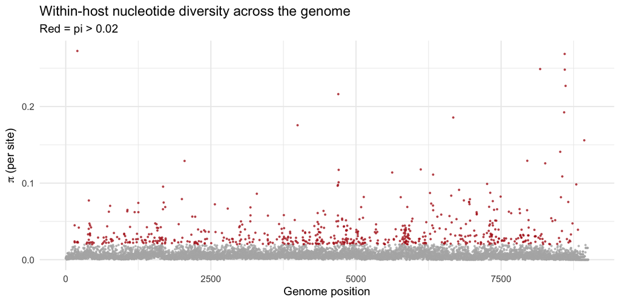

```r
ggplot(div, aes(pos, pi_site)) +
  geom_point(aes(colour = pi_site > 0.02), size = 0.5, alpha = 0.7) +
  scale_colour_manual(values = c("grey70", "firebrick"), guide = "none") +
  labs(title = "Within-host nucleotide diversity across the genome",
       subtitle = "Red = pi > 0.02",
       x = "Genome position", y = expression(pi ~ "(per site)"))
```

## 5.3 Assigning sites to genes — mind the overlapping ORFs

HIV-1 is a masterclass in genomic compression: **genes overlap**, in different reading frames. `vpu` sits inside `env`; `rev`/`tat` exon 2 sit inside `env`.

A naive `case_when` assigns each site to *one* gene and **silently discards the overlaps**. Use a long-format join so a site can belong to several genes.

```r
genes <- tribble(
  ~gene,   ~start, ~end,
  "gag",     336,  1838,
  "pol",    1631,  4642,
  "vif",    4587,  5165,
  "vpr",    5105,  5396,
  "tat_e1", 5377,  5591,
  "vpu",    5608,  5856,
  "env",    5771,  8341,
  "rev_e2", 7925,  8199,
  "nef",    8343,  8963
)

# Long format: one row per (site, gene). Overlapping sites appear more than once.
long <- div %>% crossing(genes) %>% filter(pos >= start, pos <= end)

long %>% count(pos) %>% count(n, name = "n_sites") %>%
  rename(genes_per_site = n) %>%
  kable(caption = "Sites belonging to 1 vs 2 overlapping reading frames")
```

Sites belonging to 1 vs 2 overlapping reading frames

| genes_per_site | n_sites |
| --- | --- |
| 1 | 7865 |
| 2 | 685 |

```r
gene_div <- long %>%
  group_by(gene) %>%
  summarise(sites = n(), pi = mean(pi_site), H = mean(H), .groups = "drop") %>%
  arrange(desc(pi))

kable(gene_div, digits = 5, caption = "Diversity by HIV-1 gene")
```

Diversity by HIV-1 gene

| gene | sites | pi | H |
| --- | --- | --- | --- |
| vif | 579 | 0.01100 | 0.03403 |
| vpu | 240 | 0.01019 | 0.03253 |
| rev_e2 | 275 | 0.00927 | 0.02880 |
| env | 2535 | 0.00894 | 0.02818 |
| pol | 3000 | 0.00783 | 0.02622 |
| gag | 1479 | 0.00782 | 0.02596 |
| vpr | 291 | 0.00731 | 0.02448 |
| nef | 621 | 0.00694 | 0.01977 |
| tat_e1 | 215 | 0.00539 | 0.01886 |

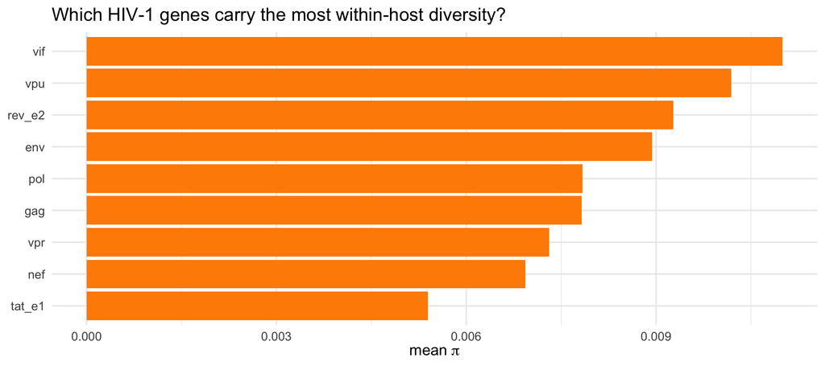

```r
ggplot(gene_div, aes(reorder(gene, pi), pi)) +
  geom_col(fill = "darkorange") + coord_flip() +
  labs(title = "Which HIV-1 genes carry the most within-host diversity?",
       x = NULL, y = expression("mean" ~ pi))
```

`env` sits high — the surface protein, under relentless antibody pressure, and tolerant of change. `pol` (drug target, structurally constrained) is lower. Diversity maps onto **selection**.

### 5.3.1 Exercise 2

Compute diversity in 100 bp windows across `env` only, and mark the **variable loops (V1–V5)**. Do they stand out as peaks?

**Predict first, then run it.** Almost everyone predicts peaks — the loops are called *variable* for a reason. In this sample they do **not** appear: mean π in the loops is 0.00903 vs 0.00893 in the conserved regions, and by *median* the loops are significantly **lower** (Wilcoxon p = 0.004).

The loops are not conserved. The explanation is in the **instrument**, and `env_minority_fasta.R` works it through: HIV’s variable loops vary mostly in **length** (7 of 12 `env` indels sit in them — a 6.8-fold rate enrichment, Poisson p = 0.0015), and a per-position pileup is indexed by reference coordinate. It has one row per reference base and no way to say *“this read carries four extra codons here.”* Length variation is invisible **by construction** — and worse, reads carrying long indels align badly, so the loops also lose coverage (94.5% callable vs 99.4%).

> The measurement, not the biology, produced the null result. Ask yourself what **other** questions this file cannot answer, no matter how carefully you filter it. Choosing the instrument comes before choosing the statistic.

# 6 Minority variants — and how to know if they are real

## 6.1 The idea

**Sanger sequencing sees ~20% and above.** Rarer variants are invisible. Deep sequencing can in principle reach **1% or below**. Variants in that gap — present, real, sub-consensus — are **minority variants**, and in HIV they matter:

- Minority **drug-resistance** mutations at 1–20% are associated with increased risk of virological failure, especially for NNRTIs (low genetic barrier).
- They are archived or transmitted, and **invisible to standard genotyping**.
- Under drug pressure a 1% variant can sweep to fixation in weeks.

## 6.2 First attempt: a binomial test against the error rate

If the per-base error rate is $\varepsilon$, then under the null “this is just error” the alt count is $\text{Binomial}(n, \varepsilon)$.

```r
eps <- params$error_rate

minor <- div %>%
  filter(minor_n > 0) %>%
  rowwise() %>%
  mutate(p_error = binom.test(minor_n, total, p = eps, alternative = "greater")$p.value) %>%
  ungroup() %>%
  mutate(q_error = p.adjust(p_error, method = "BH"))

naive <- minor %>% filter(q_error < 0.01, minor_f >= params$minor_vaf)

cat(sprintf("Assumed error rate: %.1f%%\n", 100 * eps))
```

```
## Assumed error rate: 0.2%
```

```r
cat(sprintf("Sites with any 2nd allele: %d\n", nrow(minor)))
```

```
## Sites with any 2nd allele: 8708
```

```r
cat(sprintf("Passing VAF >= %.0f%% AND FDR < 1%%: %d\n",
            100 * params$minor_vaf, nrow(naive)))
```

```
## Passing VAF >= 1% AND FDR < 1%: 451
```

451 minority variants, every one of them **statistically significant at FDR < 1%**. A tempting result. Let us try to destroy it.

## 6.3 The Ti/Tv stress test — where it falls apart

Recall: **Ti/Tv = 0.5 is what pure chance gives.** Compute Ti/Tv as a function of the VAF threshold.

```r
titv_at <- function(d) {
  d <- d %>% mutate(class = if_else(is_transition(major_base, minor_base), "Ti", "Tv"))
  ti <- sum(d$class == "Ti"); tv <- sum(d$class == "Tv")
  tibble(n = nrow(d), Ti = ti, Tv = tv, TiTv = ifelse(tv > 0, ti / tv, NA_real_))
}

thresholds <- c(0.001, 0.005, 0.01, 0.02, 0.03, 0.05, 0.10)
titv_curve <- map_dfr(thresholds, ~ titv_at(filter(minor, minor_f >= .x)) %>%
                        mutate(threshold = .x)) %>%
  select(threshold, n, Ti, Tv, TiTv)

kable(titv_curve, digits = 2,
      caption = "Ti/Tv of the minor allele as a function of VAF threshold")
```

Ti/Tv of the minor allele as a function of VAF threshold

| threshold | n | Ti | Tv | TiTv |
| --- | --- | --- | --- | --- |
| 0.00 | 6798 | 565 | 6233 | 0.09 |
| 0.00 | 1425 | 281 | 1144 | 0.25 |
| 0.01 | 451 | 151 | 300 | 0.50 |
| 0.02 | 129 | 63 | 66 | 0.95 |
| 0.03 | 57 | 29 | 28 | 1.04 |
| 0.05 | 20 | 9 | 11 | 0.82 |
| 0.10 | 8 | 4 | 4 | 1.00 |

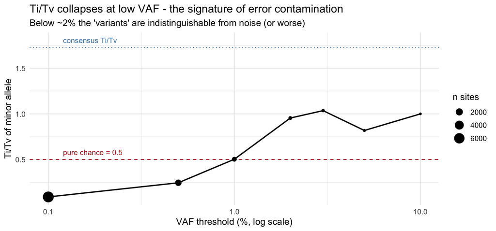

```r
ggplot(titv_curve, aes(threshold * 100, TiTv)) +
  geom_hline(yintercept = 0.5, colour = "firebrick", linetype = 2) +
  geom_hline(yintercept = titv_ratio, colour = "steelblue", linetype = 3) +
  geom_line(linewidth = 0.8) + geom_point(aes(size = n)) +
  scale_x_log10() +
  annotate("text", x = 0.12, y = 0.58, label = "pure chance = 0.5",
           colour = "firebrick", hjust = 0, size = 3.4) +
  annotate("text", x = 0.12, y = titv_ratio + 0.08, label = "consensus Ti/Tv",
           colour = "steelblue", hjust = 0, size = 3.4) +
  labs(title = "Ti/Tv collapses at low VAF - the signature of error contamination",
       subtitle = "Below ~2% the 'variants' are indistinguishable from noise (or worse)",
       x = "VAF threshold (%, log scale)", y = "Ti/Tv of minor allele", size = "n sites")
```

**This is damning.** At a 0.1% threshold Ti/Tv is ~0.09 — not merely random (0.5), but *far below* it. Random error would give 0.5. Something **worse than random** is happening: a **systematic**, direction-specific artefact.

## 6.4 Diagnosing the artefact: look at the spectrum

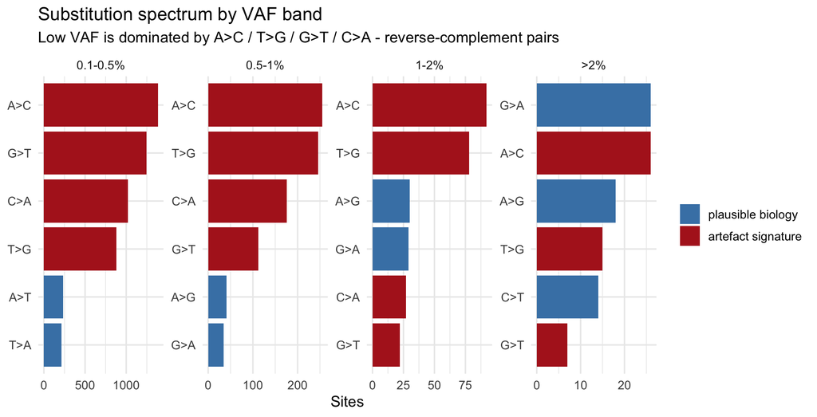

```r
bands <- minor %>%
  filter(minor_f >= 0.001) %>%
  mutate(band = cut(minor_f, c(0.001, 0.005, 0.01, 0.02, 1),
                    labels = c("0.1-0.5%", "0.5-1%", "1-2%", ">2%"),
                    include.lowest = TRUE))

art_sig <- c("A>C", "T>G", "G>T", "C>A")

bands %>%
  count(band, change) %>%
  group_by(band) %>% slice_max(n, n = 6, with_ties = FALSE) %>% ungroup() %>%
  mutate(artefact = change %in% art_sig,
         lab = paste(band, change, sep = "__"),
         lab = fct_reorder(lab, n)) %>%
  ggplot(aes(lab, n, fill = artefact)) +
  geom_col() +
  scale_x_discrete(labels = function(x) sub("^.*__", "", x)) +
  facet_wrap(~ band, scales = "free", nrow = 1) +
  coord_flip() +
  scale_fill_manual(values = c("FALSE" = "steelblue", "TRUE" = "firebrick"),
                    labels = c("plausible biology", "artefact signature"), name = NULL) +
  labs(title = "Substitution spectrum by VAF band",
       subtitle = "Low VAF is dominated by A>C / T>G / G>T / C>A - reverse-complement pairs",
       x = NULL, y = "Sites")
```

Look at what dominates the low-VAF bands: **A>C, T>G, G>T, C>A**.

Notice these form **reverse-complement pairs** (A>C ≡ T>G; G>T ≡ C>A). That is the fingerprint of a **chemical/technical artefact**, not biology:

- **G>T / C>A** is the classic **8-oxoguanine (OxoG) oxidative damage** signature — introduced during library prep, e.g. by acoustic shearing.
- **A>C / T>G** is a well-documented context-specific sequencing artefact.

Real biology has no reason to produce a transversion-only, strand-symmetric spectrum. **Sample handling does.**

## 6.5 Why the binomial test failed to catch it

```r
minor %>%
  filter(minor_f >= params$minor_vaf) %>%
  summarise(
    n = n(),
    median_depth = median(total),
    median_alt_reads = median(minor_n),
    all_significant = mean(q_error < 0.01)
  ) %>%
  kable(digits = 3, caption = "Why every 1% call passed the binomial test")
```

Why every 1% call passed the binomial test

| n | median_depth | median_alt_reads | all_significant |
| --- | --- | --- | --- |
| 451 | 3465 | 54 | 1 |

At ~4,000× depth, a 1% variant means ~40 supporting reads. Against a null of $\varepsilon = 0.2\%$, 40 reads is *overwhelmingly* significant — $p$ is astronomically small. So the test passes **every** call.

The test is not wrong; its **assumption** is. It assumes error is **uniform at 0.2% everywhere**. Real error is **context-specific and site-specific** — at some sites it is 2%. The model cannot see that, so it confidently certifies artefacts.

> **The lesson: statistical significance is not biological reality.** A p-value only ever tests the model you gave it. With enough depth you can get vanishingly small p-values for pure garbage. Deep sequencing does not protect you from this — it *guarantees* it, because depth makes everything significant.

## 6.6 The fix: filter the artefact signature and re-test

```r
div <- div %>% mutate(is_artefact_sig = change %in% art_sig)

called <- div %>%
  filter(minor_n > 0, minor_f >= params$strict_vaf, !is_artefact_sig)

titv_clean <- map_dfr(c(0.01, 0.02, 0.05), function(t) {
  titv_at(div %>% filter(minor_n > 0, minor_f >= t, !is_artefact_sig)) %>%
    mutate(threshold = t)
}) %>% select(threshold, n, Ti, Tv, TiTv)

kable(titv_clean, digits = 2,
      caption = "Ti/Tv AFTER removing the artefact signature")
```

Ti/Tv AFTER removing the artefact signature

| threshold | n | Ti | Tv | TiTv |
| --- | --- | --- | --- | --- |
| 0.01 | 177 | 151 | 26 | 5.81 |
| 0.02 | 75 | 63 | 12 | 5.25 |
| 0.05 | 11 | 9 | 2 | 4.50 |

```r
cat(sprintf("\nNaive calls (1%%, no artefact filter): %d  [Ti/Tv = %.2f]\n",
            nrow(naive), titv_at(naive)$TiTv))
```

```
##
## Naive calls (1%, no artefact filter): 451  [Ti/Tv = 0.50]
```

```r
cat(sprintf("Clean calls (%.0f%% + artefact filter):  %d  [Ti/Tv = %.2f]\n",
            100 * params$strict_vaf, nrow(called), titv_at(called)$TiTv))
```

```
## Clean calls (2% + artefact filter):  75  [Ti/Tv = 5.25]
```

**Ti/Tv jumps from 0.50 to ~5.** That is a biologically sensible number for HIV. We threw away most of our “variants” and what remains finally looks like biology.

## 6.7 Biological validation: the APOBEC3G signature

If the surviving calls are real, they should carry **biological** signal. HIV has a famous one: host **APOBEC3G** deaminates cytosine during reverse transcription, producing **G>A hypermutation** on the plus strand. `vif` exists precisely to destroy APOBEC3G.

If our clean variants are real, G>A should be **enriched at higher VAF**. Error has no reason to do that.

```r
apobec <- minor %>%
  mutate(band = cut(minor_f, c(0, 0.005, 0.01, 0.02, 0.05, 1),
                    labels = c("<0.5%", "0.5-1%", "1-2%", "2-5%", ">5%"))) %>%
  group_by(band) %>%
  summarise(n = n(), G_to_A = sum(change == "G>A"),
            pct_GtoA = 100 * mean(change == "G>A"), .groups = "drop")

kable(apobec, digits = 1, caption = "G>A (APOBEC3G signature) by VAF band")
```

G>A (APOBEC3G signature) by VAF band

| band | n | G_to_A | pct_GtoA |
| --- | --- | --- | --- |
| <0.5% | 7283 | 116 | 1.6 |
| 0.5-1% | 976 | 35 | 3.6 |
| 1-2% | 320 | 29 | 9.1 |
| 2-5% | 109 | 22 | 20.2 |
| >5% | 20 | 4 | 20.0 |

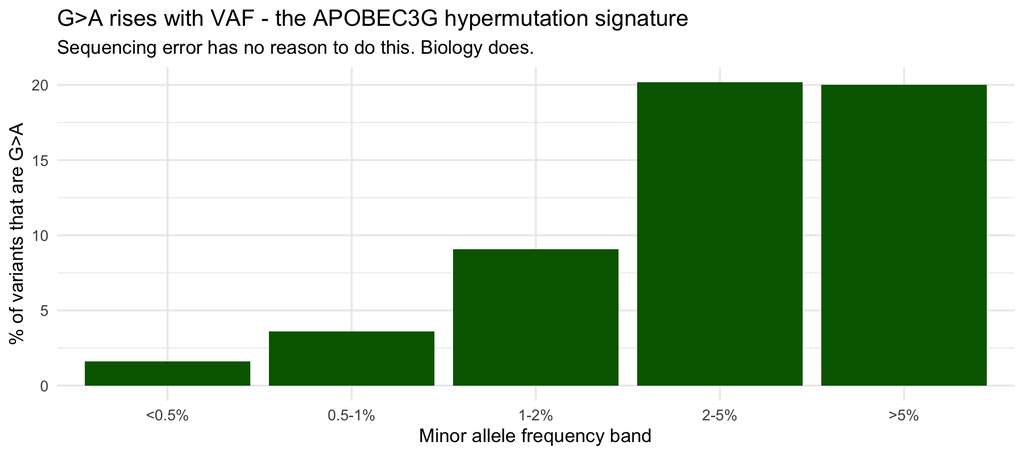

```r
ggplot(apobec, aes(band, pct_GtoA)) +
  geom_col(fill = "darkgreen") +
  labs(title = "G>A rises with VAF - the APOBEC3G hypermutation signature",
       subtitle = "Sequencing error has no reason to do this. Biology does.",
       x = "Minor allele frequency band", y = "% of variants that are G>A")
```

**G>A climbs from ~1.6% to ~20% as VAF rises.** The higher-frequency variants are enriched for a *specific, known, host-driven biological process*. This is independent confirmation that the surviving calls are real — and that the low-VAF tier is not.

### 6.7.1 Exercise 3

We justified 2% empirically, from Ti/Tv and the artefact spectrum — *not* by convention. Now defend it to a clinician. What would you need to state alongside “we found N minority variants” for the claim to be reproducible?

# 7 Burden testing

## 7.1 What a burden test is, and why it exists

Single-variant tests work for **common** variants. For **rare** variants they fail — if a variant appears in 3 of 5,000 people, nothing has power to associate it with anything.

The burden test’s move is **collapsing**: stop testing variants, test **units** (a gene, a region, a domain).

> Instead of “does variant X associate with disease?”, ask **“do carriers of *any* rare variant in gene G differ from non-carriers?”**

You trade *resolution* for *power*: you no longer know which variant matters, but you can detect that the gene matters.

| Test | Collapsing rule | Best when |
| --- | --- | --- |
| **CAST** | binary: carries ≥1 rare variant | variants rare, effects same direction |
| **Burden / MB** | count, optionally weighted by rarity | effects same direction |
| **SKAT** | variance-component; allows mixed directions | some protective, some harmful |
| **SKAT-O** | data-driven blend of Burden and SKAT | you don’t know which — the safe default |

**Critical weakness:** a plain burden test assumes all variants push the **same way**. If half are harmful and half protective they cancel, and it sees nothing. That is why SKAT exists, and why SKAT-O is the sensible default.

## 7.2 An honest note on this dataset

A classical burden test compares **cases vs controls** across **many individuals**. We have **one sample**, so we *cannot* run one — be suspicious of anyone who claims otherwise.

What we *can* do is the same **machinery** in its within-sample form: collapse variants into genes and test each against a background rate. This is legitimate (it is how regional mutation-enrichment scans work in cancer genomics) and it drills the identical logic. Then we simulate a cohort for the case/control version.

## 7.3 Burden version 1: regional enrichment — the naive run

**Null:** minority variants fall uniformly at the genome-wide rate. **Alternative:** this gene carries more than its share.

Let us first run it on the **naive 1% calls** — the ones we now know are contaminated.

```r
burden_test <- function(call_set, label) {
  bg <- nrow(call_set) / nrow(div)
  long %>%
    count(gene, name = "sites") %>%
    left_join(
      call_set %>% crossing(genes) %>% filter(pos >= start, pos <= end) %>%
        count(gene, name = "observed"),
      by = "gene"
    ) %>%
    mutate(
      observed = replace_na(observed, 0),
      expected = sites * bg,
      fold     = observed / expected,
      p_value  = pbinom(observed - 1, sites, bg, lower.tail = FALSE),
      q_value  = p.adjust(p_value, method = "BH"),
      analysis = label
    ) %>%
    arrange(p_value)
}

burden_naive <- burden_test(naive, "naive (1%, no artefact filter)")

burden_naive %>%
  select(gene, sites, observed, expected, fold, p_value, q_value) %>%
  kable(digits = c(0, 0, 0, 2, 2, 6, 4),
        caption = "NAIVE burden: minority variants per gene (1% threshold)")
```

NAIVE burden: minority variants per gene (1% threshold)

| gene | sites | observed | expected | fold | p_value | q_value |
| --- | --- | --- | --- | --- | --- | --- |
| vif | 579 | 52 | 29.26 | 1.78 | 0.000058 | 0.0005 |
| env | 2535 | 170 | 128.11 | 1.33 | 0.000161 | 0.0007 |
| vpu | 240 | 19 | 12.13 | 1.57 | 0.036761 | 0.1103 |
| rev_e2 | 275 | 19 | 13.90 | 1.37 | 0.106050 | 0.2386 |
| gag | 1479 | 76 | 74.75 | 1.02 | 0.457316 | 0.7589 |
| vpr | 291 | 15 | 14.71 | 1.02 | 0.505925 | 0.7589 |
| nef | 621 | 20 | 31.38 | 0.64 | 0.989383 | 0.9953 |
| pol | 3000 | 125 | 151.61 | 0.82 | 0.989722 | 0.9953 |
| tat_e1 | 215 | 4 | 10.87 | 0.37 | 0.995342 | 0.9953 |

**A beautiful result!** `vif` is enriched 1.8-fold, q < 0.001. `env` 1.3-fold, q < 0.001. We could write this up: *“vif carries a significant excess of minority variants.”*

It is wrong. `vif` is an artefact.

## 7.4 Burden version 2: the same test on clean calls

```r
burden_clean <- burden_test(called, "clean (2% + artefact filter)")

burden_clean %>%
  select(gene, sites, observed, expected, fold, p_value, q_value) %>%
  kable(digits = c(0, 0, 0, 2, 2, 6, 4),
        caption = "CLEAN burden: artefact signature removed, 2% threshold")
```

CLEAN burden: artefact signature removed, 2% threshold

| gene | sites | observed | expected | fold | p_value | q_value |
| --- | --- | --- | --- | --- | --- | --- |
| env | 2535 | 37 | 21.30 | 1.74 | 0.001211 | 0.0109 |
| nef | 621 | 8 | 5.22 | 1.53 | 0.156379 | 0.6535 |
| vif | 579 | 7 | 4.87 | 1.44 | 0.217828 | 0.6535 |
| rev_e2 | 275 | 3 | 2.31 | 1.30 | 0.407272 | 0.9164 |
| vpu | 240 | 2 | 2.02 | 0.99 | 0.599737 | 1.0000 |
| vpr | 291 | 1 | 2.45 | 0.41 | 0.914222 | 1.0000 |
| pol | 3000 | 17 | 25.21 | 0.67 | 0.965972 | 1.0000 |
| gag | 1479 | 6 | 12.43 | 0.48 | 0.984807 | 1.0000 |
| tat_e1 | 215 | 0 | 1.81 | 0.00 | 1.000000 | 1.0000 |

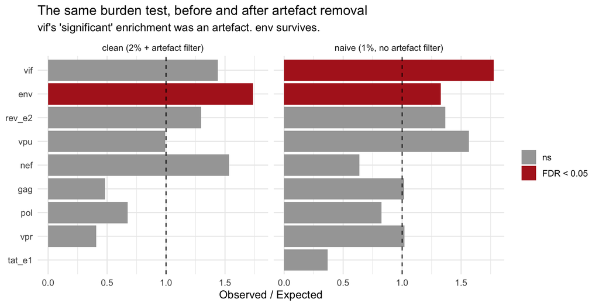

```r
bind_rows(burden_naive, burden_clean) %>%
  mutate(sig = q_value < 0.05) %>%
  ggplot(aes(reorder(gene, fold), fold, fill = sig)) +
  geom_col() +
  geom_hline(yintercept = 1, linetype = 2) +
  coord_flip() +
  facet_wrap(~ analysis) +
  scale_fill_manual(values = c("FALSE" = "grey65", "TRUE" = "firebrick"),
                    labels = c("ns", "FDR < 0.05"), name = NULL) +
  labs(title = "The same burden test, before and after artefact removal",
       subtitle = "vif's 'significant' enrichment was an artefact. env survives.",
       x = NULL, y = "Observed / Expected")
```

```r
bind_rows(burden_naive, burden_clean) %>%
  filter(gene %in% c("vif", "env")) %>%
  select(analysis, gene, observed, fold, q_value) %>%
  arrange(gene, analysis) %>%
  kable(digits = c(0, 0, 0, 2, 5), caption = "The verdict on vif and env")
```

The verdict on vif and env

| analysis | gene | observed | fold | q_value |
| --- | --- | --- | --- | --- |
| clean (2% + artefact filter) | env | 37 | 1.74 | 0.01090 |
| naive (1%, no artefact filter) | env | 170 | 1.33 | 0.00073 |
| clean (2% + artefact filter) | vif | 7 | 1.44 | 0.65348 |
| naive (1%, no artefact filter) | vif | 52 | 1.78 | 0.00052 |

**What happened.**

- **`vif`**: fold 1.8 → 1.4, q 0.0005 → **non-significant**. Its “enrichment” was driven by artefact-signature calls (≈77% of its 1% calls were A>C/T>G/G>T/C>A). A confident, FDR-corrected, *entirely false* result.
- **`env`**: fold 1.3 → **1.7**, and *still* significant after correction. It got **stronger** when noise was removed — the hallmark of real signal, and exactly what HIV biology predicts for the antibody-facing envelope protein.

> **The single most important slide of this workshop.** Multiple-testing correction did not save us. FDR controls for *chance*; it is completely blind to *systematic bias*. Your q-value was 0.0005 and the result was still garbage. No amount of statistics rescues contaminated input.

## 7.5 Burden version 3: case/control (simulated cohort)

The classic design, on simulated data so the logic is visible: 20 failing, 20 suppressed; are rare variants in a gene enriched in failures?

```r
set.seed(42)
n_case <- 20; n_ctrl <- 20; n_var <- 15

sim_gene <- function(effect) {
  rbind(
    matrix(rbinom(n_case * n_var, 1, 0.02 + effect), nrow = n_case),  # cases
    matrix(rbinom(n_ctrl * n_var, 1, 0.02),          nrow = n_ctrl)   # controls
  )
}

pheno <- c(rep(1, n_case), rep(0, n_ctrl))

run_burden <- function(G, label) {
  carrier <- as.integer(rowSums(G) > 0)          # CAST: carrier yes/no
  cast_p  <- fisher.test(table(carrier, pheno))$p.value
  load    <- rowSums(G)                          # Burden: count
  burd_p  <- summary(glm(pheno ~ load, family = binomial))$coefficients[2, 4]
  tibble(gene = label,
         mean_load_case = mean(load[pheno == 1]),
         mean_load_ctrl = mean(load[pheno == 0]),
         CAST_p = cast_p, Burden_p = burd_p)
}

bind_rows(
  run_burden(sim_gene(0.00), "null_gene (no effect)"),
  run_burden(sim_gene(0.12), "causal_gene (true effect)")
) %>%
  kable(digits = 4, caption = "Simulated case/control burden: CAST vs count-based Burden")
```

Simulated case/control burden: CAST vs count-based Burden

| gene | mean_load_case | mean_load_ctrl | CAST_p | Burden_p |
| --- | --- | --- | --- | --- |
| null_gene (no effect) | 0.2 | 0.3 | 1e+00 | 0.5203 |
| causal_gene (true effect) | 2.1 | 0.3 | 3e-04 | 0.0013 |

The causal gene shows a significant burden; the null gene does not. That is the engine of rare-variant association testing — the same collapsing logic we applied to genes above.

### 7.5.1 Exercise 4

In `run_burden`, make **half** the variants protective (flip their direction in cases). Re-run and watch the burden test’s power **collapse**. Then explain in one sentence why SKAT exists.

# 8 Putting it together

```r
tibble(
  Metric = c(
    "SNP-comparable sites", "Callable sites (>= 100x)", "Median depth",
    "Consensus mutations vs reference", "% divergence from NC_001802.1",
    "Consensus Ti/Tv", "Indel records",
    "Mean Shannon entropy", "Nucleotide diversity (pi)",
    "NAIVE minority variants (1%, FDR<1%)", "  their Ti/Tv (= noise line)",
    "CLEAN minority variants (2% + artefact filter)", "  their Ti/Tv",
    "Discarded as artefact",
    "Genes significant, naive burden", "Genes significant, clean burden"
  ),
  Value = c(
    format(nrow(snp), big.mark = ","), format(nrow(callable), big.mark = ","),
    format(median(snp$depth_hq), big.mark = ","),
    format(nrow(cons), big.mark = ","),
    sprintf("%.2f%%", 100 * nrow(cons) / nrow(callable)),
    sprintf("%.2f", titv_ratio), format(nrow(ind), big.mark = ","),
    sprintf("%.4f", mean(div$H)), sprintf("%.5f", mean(div$pi_site)),
    format(nrow(naive), big.mark = ","), sprintf("%.2f", titv_at(naive)$TiTv),
    format(nrow(called), big.mark = ","), sprintf("%.2f", titv_at(called)$TiTv),
    sprintf("%d (%.0f%%)", nrow(naive) - nrow(called),
            100 * (1 - nrow(called) / nrow(naive))),
    paste(burden_naive$gene[burden_naive$q_value < 0.05], collapse = ", "),
    paste(burden_clean$gene[burden_clean$q_value < 0.05], collapse = ", ")
  )
) %>% kable(caption = "Workshop summary: one sample, every metric")
```

Workshop summary: one sample, every metric

| Metric | Value |
| --- | --- |
| SNP-comparable sites | 9,005 |
| Callable sites (>= 100x) | 8,924 |
| Median depth | 4,002 |
| Consensus mutations vs reference | 1,287 |
| % divergence from NC_001802.1 | 14.42% |
| Consensus Ti/Tv | 1.73 |
| Indel records | 26 |
| Mean Shannon entropy | 0.0262 |
| Nucleotide diversity (pi) | 0.00810 |
| NAIVE minority variants (1%, FDR<1%) | 451 |
| their Ti/Tv (= noise line) | 0.50 |
| CLEAN minority variants (2% + artefact filter) | 75 |
| their Ti/Tv | 5.25 |
| Discarded as artefact | 376 (83%) |
| Genes significant, naive burden | vif, env |
| Genes significant, clean burden | env |

## 8.1 The six things to take away

1. **“Mutation” is a comparison.** State: relative to what, at what frequency, with what confidence. Difference-from-reference ≠ mutation that arose in your sample — 14% of this genome differs from HXB2 because it is a different subtype, not because the patient mutated.
2. **Frequency ≠ rate.** One timepoint gives a snapshot, never a speed.
3. **Diversity ≠ divergence.** Independent axes — and diversity maps onto selection (`env` high, `pol` constrained).
4. **Your threshold and depth define your variant count.** 451 variants at 1%, 75 at 2% with artefact filtering. Neither is “the truth” — report threshold **and** depth, or report nothing.
5. **Ti/Tv is your lie detector.** 0.5 = noise. If your minority calls sit at 0.5, they are noise — no matter how small the p-value.
6. **Statistics cannot rescue contaminated data.** We got q = 0.0005 for `vif` and it was pure artefact. FDR controls chance, not bias. Only the *biology* — Ti/Tv, the OxoG spectrum, the APOBEC signature — told us the truth.